# Module 7: Models with changing variance and frequency models

## Learning outcomes

- Understand how to fit ARCH, GARCH and SVM models in JAGS
- Know how to check assumptions for these methods
- Understand the basis of seasonal models
- Know the difference between time and frequency domain models and be able to implement a Fourier model

Relevant JAGS file:

```
jags_ARCH.R
jags_GARCH.R
jags_SVM.R
jags_Fourier.R
```

## General principles of models for changing variance

- So far we have looked at models where the mean changes but the variance is constant:\[y_t \sim N(\mu_t, \sigma^2)\]
- In this module we look at methods where instead:\[y_t \sim N(\alpha, \sigma_t^2)\]
- These are:
- Autoregressive Conditional Heteroskedasticity (ARCH)
- Generalised Autoregressive Conditional Heteroskedasticity (GARCH)
- Stochastic Volatility Models (SVM)

## JAGS code for ARCH models

```r
model_code = '
model
{
  # Likelihood
  for (t in 1:T) {
    y[t] ~ dnorm(alpha, tau[t])
    tau[t] <- 1/pow(sigma[t], 2)
  }
  sigma[1] ~ dunif(0, 10)
  for(t in 2:T) {
    sigma[t] <- sqrt( gamma_1 + gamma_2 * pow(y[t-1] - alpha, 2) )
  }

  # Priors
  alpha ~ dnorm(0.0, 0.01)
  gamma_1 ~ dunif(0, 10)
  gamma_2 ~ dunif(0, 1)
}
'
```

## Example: ice core data

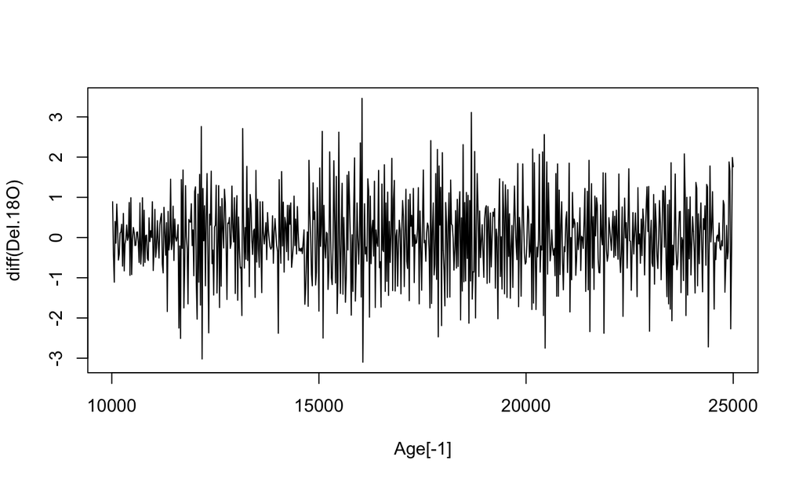

```r
with(ice2,plot(Age[-1],diff(Del.18O),type='l'))
```

## Example: ice core output

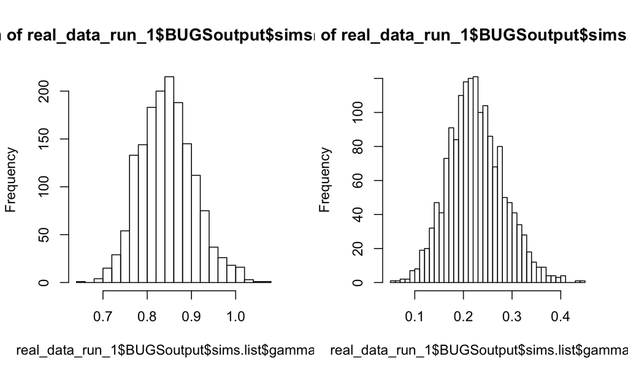

```r
par(mfrow=c(1,2))
hist(real_data_run_1$BUGSoutput$sims.list$gamma_1, breaks=30)
hist(real_data_run_1$BUGSoutput$sims.list$gamma_2, breaks=30)
```

## Example: posterior standard deviations

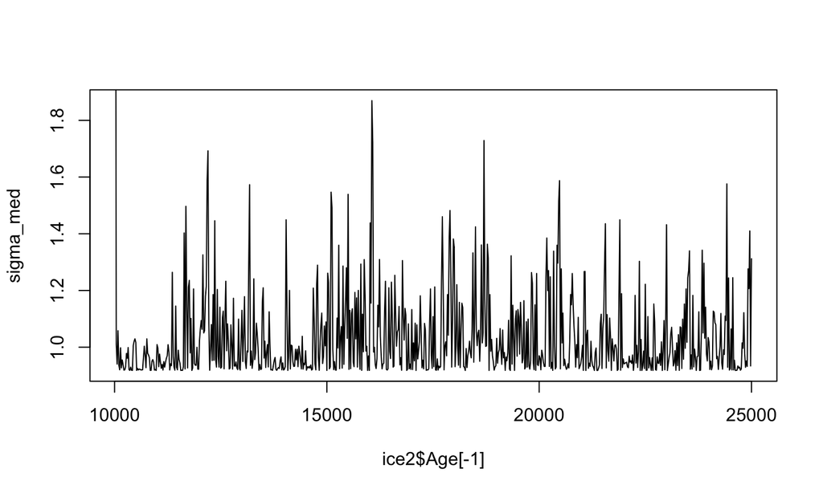

```r
sigma_med = apply(real_data_run_1$BUGSoutput$sims.list$sigma,2,'quantile',0.5)
plot(ice2$Age[-1],sigma_med,type='l',ylim=range(c(sigma_med[-1])))
```

## Example of using the GARCH(1,1) model

```r
model_code = '
model
{
  # Likelihood
  for (t in 1:T) {
    y[t] ~ dnorm(alpha, tau[t])
    tau[t] <- 1/pow(sigma[t], 2)
  }
  sigma[1] ~ dunif(0,10)
  for(t in 2:T) {
    sigma[t] <- sqrt( gamma_1 + gamma_2 * pow(y[t-1] - alpha, 2) + gamma_3 * pow(sigma[t-1], 2) )
  }

  # Priors
  alpha ~ dnorm(0.0, 0.01)
  gamma_1 ~ dunif(0, 10)
  gamma_2 ~ dunif(0, 1)
  gamma_3 ~ dunif(0, 1)
}
'
```

## Using the ice core data again

Have a look at the ARCH parameters;

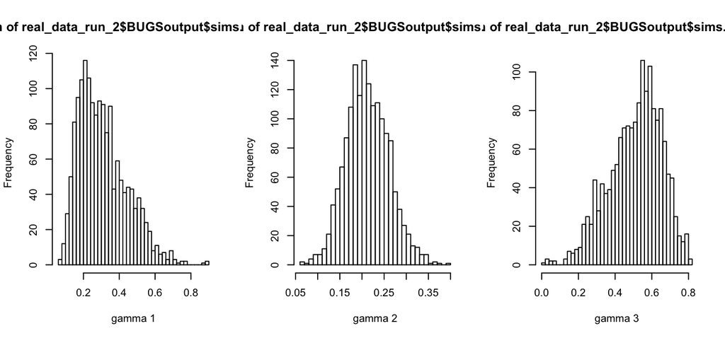

```r
par(mfrow=c(1,3))
hist(real_data_run_2$BUGSoutput$sims.list$gamma_1, breaks=30, xlab = 'gamma 1')
hist(real_data_run_2$BUGSoutput$sims.list$gamma_2, breaks=30, xlab = 'gamma 2')
hist(real_data_run_2$BUGSoutput$sims.list$gamma_3, breaks=30, xlab = 'gamma 3')
```

## Posterior median standard deviation

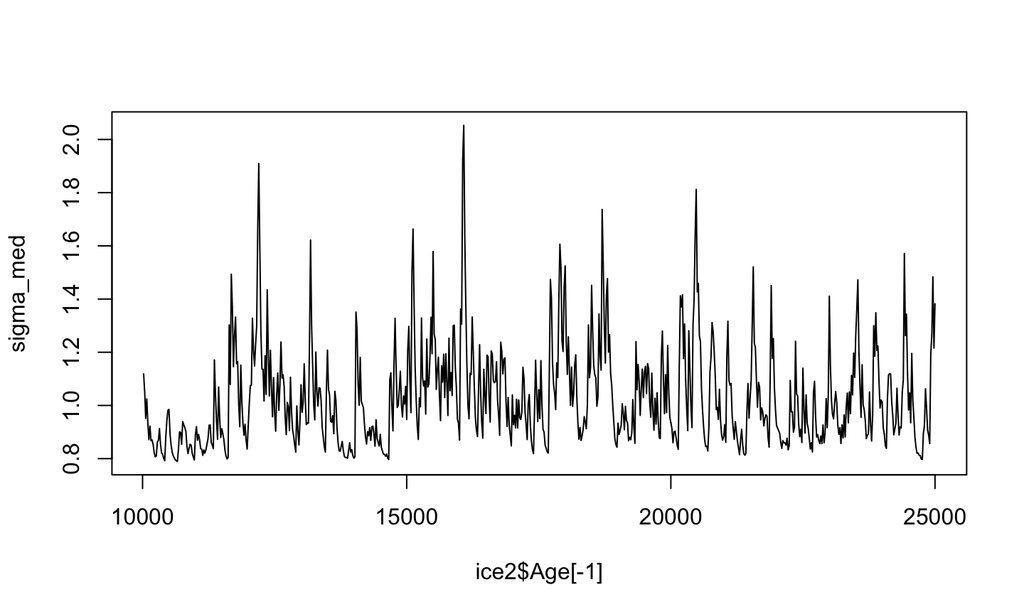

```r
sigma_med = apply(real_data_run_2$BUGSoutput$sims.list$sigma, 2, 'quantile', 0.5)
plot(ice2$Age[-1], sigma_med, type='l', ylim=range(c(sigma_med)))
```

## Compare with DIC

```r
with(r_1, print(c(DIC, pD)))
```

```
## [1] 2153.014741    3.798524
```

```r
with(r_2, print(c(DIC, pD)))
```

```
## [1] 2142.823499    7.723047
```

- Suggests full GARCH model is best, despite the extra parameters

## Stochastic Volatility Modelling

- Both ARCH and GARCH propose a deterministic relationship for the current variance parameter
- By contrast a Stochastic Volatility Model (SVM) models the variance as its own *stochastic process*
- SVMs, ARCH and GARCH are all closely linked if you go into the bowels of the theory
- The general model structure is often written as:\[y_t \sim N( \alpha, \exp( h_t ) )\]\[h_t \sim N( \mu + \phi ( h_{t-1} - \mu), \sigma^2)\]
- You can think of an SVM being like a GLM but with a log link on the variance parameter

## JAGS code for the SVM model

```r
model_code = '
model
{
  # Likelihood
  for (t in 1:T) {
    y[t] ~ dnorm(alpha, tau_h[t])
    tau_h[t] <- 1/exp(h[t])
  }
  h[1] <- mu
  for(t in 2:T) {
    h[t] ~ dnorm(mu + phi * (h[t-1] - mu), tau)
  }

  # Priors
  alpha ~ dnorm(0, 0.01)
  mu ~ dnorm(0, 0.01)
  phi ~ dunif(-1, 1)
  tau <- 1/pow(sigma, 2)
  sigma ~ dunif(0,100)
}
'
```

## Example of SVMs and comparison of DIC

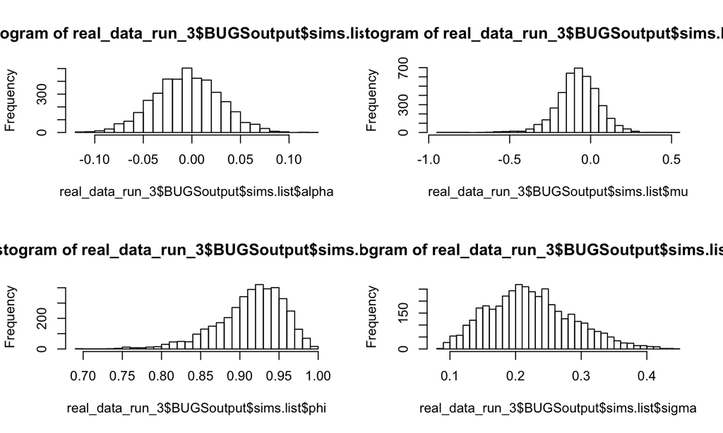

## Plot of \(h\)

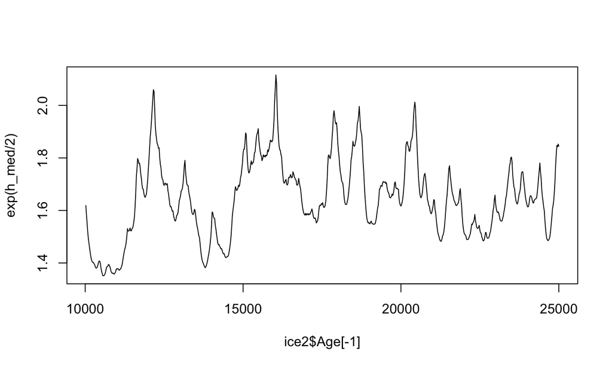

```r
h_med = exp(apply(real_data_run_3$BUGSoutput$sims.list$h,2,'quantile',0.5)/2)
plot(ice2$Age[-1],exp(h_med/2),type='l',ylim=range(c(exp(h_med[-1]/2))))
```

## Comparison with previous models

```r
with(r_1, print(c(DIC, pD)))
```

```
## [1] 2153.014741    3.798524
```

```r
with(r_2, print(c(DIC, pD)))
```

```
## [1] 2142.823499    7.723047
```

```r
with(r_3, print(c(DIC, pD)))
```

```
## [1] 2250.4560  174.1445
```

Note quite as good, and many extra parameters due to \(h\)!

## Seasonal time series

- So far we haven't covered how to deal with data that are *seasonal* in nature
- These data generally fall into two categories:
  1. Data where we know the frequency or frequencies (e.g. monthly data on a yearly cycle, frequency = 12)
  2. Data where we want to estimate the frequencies (e.g. climate time series, animal populations, etc)
- The former are much simpler, as we can e.g. use month as a covariate in an ARIMAX model, perform a seasonal difference with an ARIMA, or fit a full seasonal ARIMA model (though the JAGS code for this gets complicated)
- The latter are much more interesting. The ACF and PACF can help, but we can usually do much better by creating a *power spectrum*

## Methods for estimating frequencies

- The most common way to estimate the frequencies in a time series is to decompose it in a *Fourier Series*
- We write:\[ y_t = \alpha + \sum_{k=1}^K \left[ \beta_k \sin (2 \pi t f_k) + \gamma_k \cos (2 \pi t f_k) \right] + \epsilon_t\]
- Each one of the terms inside the sum is called a *harmonic*. We decompose the series into a sum of sine and cosine waves rather than with AR and MA components
- Each sine/cosine pair has its own frequency \(f_k\). If the corresponding coefficients \(\beta_k\) and \(\gamma_k\) are large we might believe this frequency is important

## Estimating frequencies via a Fourier model

- It's certainly possible to fit the model in the previous slide in JAGS, as it's just a linear regression model with clever explanatory variables
- However, it can be quite slow to fit and, if the number of frequencies \(K\) is high, or the frequencies are close together, it can struggle to converge
- More commonly, people repeatedly fit the simpler model:\[ y_t = \alpha + \beta \sin (2 \pi t f_k) + \gamma \cos (2 \pi t f_k) + \epsilon_t\]for lots of different values of \(f_k\). Then calculate the *power spectrum* as \(P(f_k) = \frac{\beta^2 + \gamma^2}{2}\). Large values of the power spectrum indicate important frequencies
- It's much faster to do this outside of JAGS, using other methods, but we will stick to JAGS

## JAGS code for a Fourier model

```r
model_code = '
model
{
  # Likelihood
  for (t in 1:T) {
    y[t] ~ dnorm(mu[t], tau)
    mu[t] <- alpha + beta * cos( 2 * pi * t * f_k ) + gamma * sin( 2 * pi * t * f_k )
  }
  P = ( pow(beta, 2) + pow(gamma, 2) ) / 2

  # Priors
  alpha ~ dnorm(0.0,0.01)
  beta ~ dnorm(0.0,0.01)
  gamma ~ dnorm(0.0,0.01)
  tau <- 1/pow(sigma,2) # Turn precision into standard deviation
  sigma ~ dunif(0.0,100.0)
}
'
```

## Example: the Lynx data

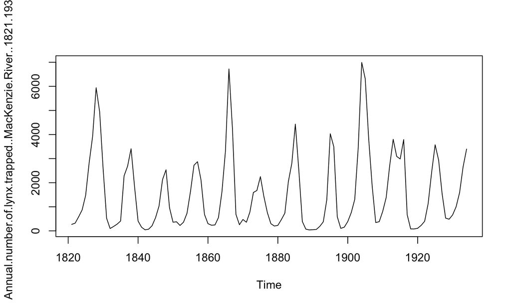

```r
lynx = as.ts(dmseries('http://data.is/Ky69xY'))
plot(lynx)
```

## Code to run the JAGS model repeatedly

```r
periods = 5:40
K = length(periods)
f = 1/periods
Power = rep(NA,K)
model_parameters =  c("P")

for (k in 1:K) {
  curr_model_data = list(y = as.vector(lynx[,1]),
                         T = length(lynx),
                         f_k = f[k],
                         pi = pi)

  model_run = jags(data = curr_model_data,
                   parameters.to.save = model_parameters,
                   model.file=textConnection(model_code),
                   n.chains=4,
                   n.iter=1000,
                   n.burnin=200,
                   n.thin=2)

  Power[k] = mean(model_run$BUGSoutput$sims.list$P)
}
```

## Plotting the periodogram

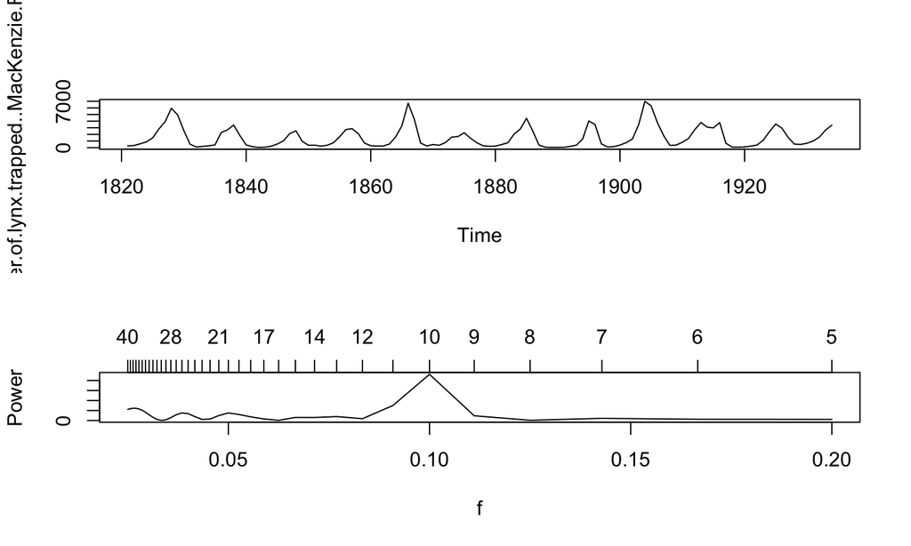

```r
par(mfrow = c(2, 1))
plot(lynx)
plot(f, Power, type='l')
axis(side = 3, at = f, labels = periods)
```

## Bayesian vs traditional frequency analysis

- For quick and dirty analysis, there is no need to run the full Bayesian model, the R function `periodogram` in the TSA package will do the job
- However, the big advantage (as always with Bayes) is that we can also plot the uncertainty in the periodogram, or combine the Fourier model with other modelling ideas (e.g. ARIMA)
- There are much fancier versions of frequency models out there (e.g. Wavelets, or frequency selection models) which can also be fitted in JAGS but require a bit more time and effort
- These Fourier models work for continuous time series too

## Summary

- We now know how to fit models with changing variance using a variety of techniques
- We can combine these new models with all the techniques we have previously learnt
- With known periodicity we can use seasonal differencing (or seasonal AR terms, not covered here but can be upon request)
- We've seen a basic Fourier model for estimating frequencies via the Bayesian periodogram